# Report GUI Program

## Overview

This program provides a Graphical User Interface for a user to query a relational database. The GUI allows two reports to be run against a music store database. The database has stored data from an online service that allows customers to create playlists of music in several genres.

This project requires you to complete the code provided so that the program produces the intended output for the reports.

## Setup

First, you need to download the project from github. The files included are: `report_gui.py`, `report_model.py`, `dbaccessor.py` (the `submit.py` script is also provided for convenience).

The database you will work with is created by running this file in sqlite3: `MusicStoreCreate_Sqlite.sql`. The data load is in the file `MusicStoreData_Sqlite.sql`, which you also run from the sqlite3 command line. See the lab9 material for details. Run the create script so that you produce the file `music.db`. Note: the data file may take some time to fully load- run it, then go have a beverage and come back.

NOTE: In the sql files you might have to change the EOL character to unix LF. In notepad++ this is: edit/EOL conversion/unix LF.

After the database has been created and the data loaded, run a few simple queries from the sqlite3 command line to test it. Then, go to the dbaccessor module and run a very simple query to test the connection from the python application.

At that point you can start to build the rest of the program.

## Development Tasks:

The code for this assignment resembles the code in Lab10. For this project, you are given the `report_model.py` file to use- it requires no development, and you are to use it as-is with no modifications.

The`report_gui.py` module needs to be completed as does the `dbaccessor.py` module.

Suggestion: start by implementing the All Customers report. Write a simple query to begin with, such as `select * from customer;`. In the GUI class, call the dbaccessor function to get the result set, then call the model function to return a model that can be used by the table view object to display the results.

Your GUI should look like the following screen shots.

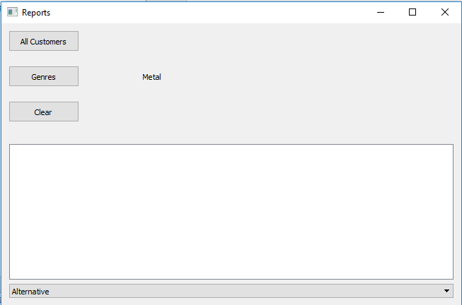

Fig. 1: Start-up appearance.

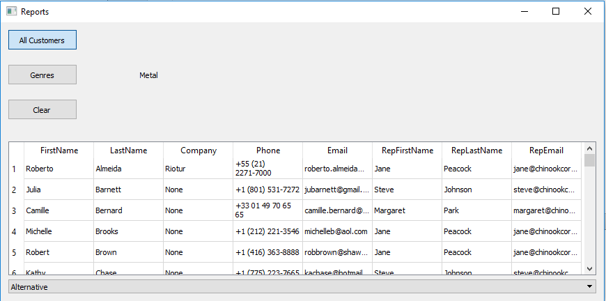

Fig. 2: The All Customers Report.

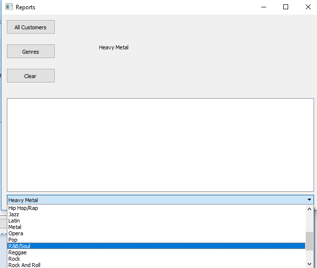

Fig. 3: Using the Combo-Box Dropdown to select a Genre.

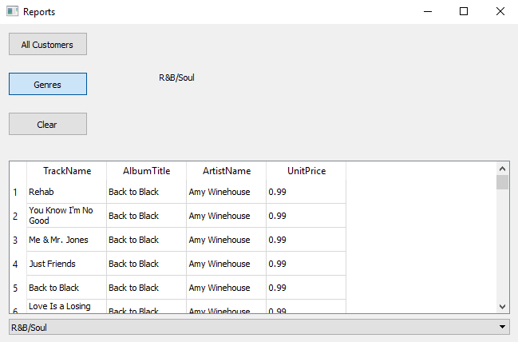

Fig. 4: Running the “Genres” Report.

The GUI code is mostly provided for you. Your job in the GUI class is to make the appropriate calls to the `dbaccessor` and `report_model` to obtain the model that can be set into the appropriate view object. The combo-box will need the genre names, while the other reports will use the table view object. Writing the queries is the other part of this project.

## The Database

You will write three SQL queries for this project. Two of them involve joining several tables to achieve the desired report. Be sure to refer to the ER diagram, the SQL create script, as well as the SQL material provided in this course when writing and testing your queries.

The databse stores data about customers and tracks of music they define to make up playlists. You will be concerned with only several of the tables in this database.

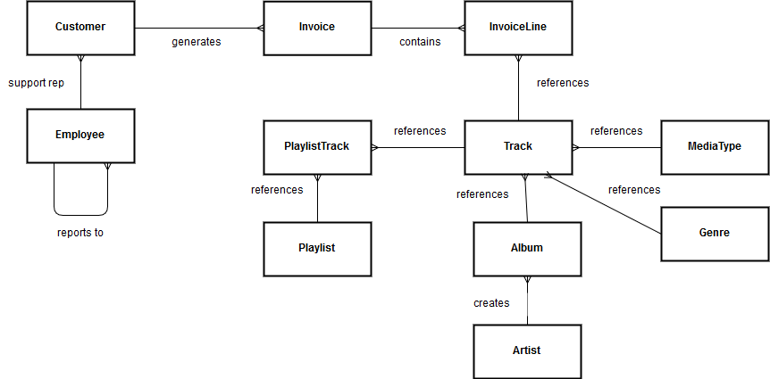

Fig. 5: ER Diagram of the Music database.

This ER diagram uses “crow’s foot” notation. The many side of the relationship is represented by three little line that spread out in a “crow’s foot”. For example, each Customer has one Employee as a support rep, and each Employee can be a support rep to many Customers. Note that in the databse schema, which can be seen in the create sql script file, the many side is implemented as foreign keys, so that a Customer has an EmployeeID (named SupportRepId) as a foreign key. (refer to the SQL material). The lower bounds on the relationships are omitted in the ER diagram for brevity. You do not need to worry about them. Although there are many tables in the database, you will only deal with a few of them. In order to see the names of the fields you need for your queries, refer to the create sql script.

## The Reports and Supporting Queries:

#### The “All Customers” Report Query.

Consult the schema in the create sql file for the key names to use in your join. For example, the Customer table’s “SupportRepId” column is the foreign key that connects it to the Employee “EmployeeID” column, the primary key in the Employee table. This implements the many to one relationship.

#### The “All Genres Query”

This simple query retrieves only the names of all genres in the database. This result set, a single column, is used to populate the combo-box when the program loads. Be sure to sort by the name in lexicographical (dictionary) order. See Fig 3 above.

#### The “Genres” Report Query

This query produces the following data for a genre that was selected by the combo-box: The TrackName, AlbumTitle, ArtistName, and the track.unitprice. Use aliases to match the report header shown in Fig 4 above. The Track table is the basis for this query. We are not using the Playlist table.

Refer to the ER diagram above (Fig 5) to see that the Track table has one to many relationships with the Album and Genre tables. The Artist table is related to the Album table. Sort by the artist’s name in dictionary order.

This query is “parameterized” in that it receives a genre name. This name is used in the query as a constraint so that only rows in the return that are of that genre type will be returned. Suggestion: you can include the genre name in the select clause of your query to test that you have this correct. Don’t forget to remove that from the report before submitting the final code.

## Additional Notes

Notes: You should develop and test your code in a step-by-step manner to ensure that it is working properly. Do not write all of this code at once and then test - it will be too confusing and harder to debug. You should implement simple queries first and then run tests to see if it works. You should run your code at the end to ensure that it performs as specified.

## Task 4: Submit Your Work

Submit only the `report_gui.py`, `report_model.py`, `dbaccessor.py` files for this assignment. Do NOT include any of the databse files. Use the `submit.py` script as usual.